# Final Tutorial: Predicting College Quarterback's success in the NFL

Every year, struggling nfl franchise turn to the NFL Draft to pick a new quarterback. Often regarded as the most important player on the team, quarterbacks have to use a lot of skills, and it has been an ongoing challenge to determine what a quarterback's potential is, and how their game will translate to the next level.

Starting the day after the last year's NFL Draft, experts and scouts spend countless days trying to determine which quarterbacks will pan out the best. While this investigation is by no means exhaustive, as a quarterback's ability goes beyond statistics and 2 physical measures, and encorporates a lot of intangible features such as footwork and football IQ, it does offer insight as to what statistics seem to have a higher impact on determining NFL Success, and offers and interesting deliverable of future Draft predictions.

As noted, this is a very important topic in the world of football, and as such creates a lot of media attention. A few articles I found interesting as a sports nut about the topic are:

- Discussion of NFL Quarterback evaluation challenges: http://www.espn.com/nfl/story/_/id/23039883/history-tells-us-nfl-terrible-evaluating-quarterbacks-means-2018-draft-prospects
- Top 50 Quarterback Busts of All-Time: https://bleacherreport.com/articles/1047730-50-biggest-quarterback-busts-in-nfl-draft-history#slide49

In this tutorial, I look to examine how some factors regarding collegiate quarterbacks tend to translate to professionals, especially in the capacity of quarterbacks considered for early round draft picks (determined to be before or on the 128th pick). The factors examined were:

1. Height
2. Weight
3. Completion Percentage
4. TD to Interception Ratio
5. College Quarterback Rating

These factors are widely looked at as being very influential in determining a college quarterback's NFL readiness, along with other things such as feel for the game, arm strength, footwork, etc. that are a lot harder to quantify without access to specific data.

From these characteristics, I created a fitted multivariable linear regression that I then used to predict NFL Quarterback performance by means of NFL QBR (quarterback rating). This stat is essentially a measure of a quarterback's success and efficiency, and seemed to be the best possible option when fitting my regression.

## 1. DATA COLLECTION

Data collection for this project was done by using BeautifulSoup (link below) in order to help aid in website scraping on 3 websites denoted later. After the scraping was finished, the file was exported to quarterback_data.csv, where the data I used in later analysis and exploration is accessible.

Some interesting features to the website scraping I did was that for 2 of the websites, I was searching and finding players through a process that sometimes took me through multiple pages. Whereas easier/trivial scraping (like the first website I used) just requires reading in information off a given website, jumping from page to page requires more attention to detail. It mean multiple url requests that had to be formatted to meet the websites criteria, and also required finding the correct links for redirection. In addition, the websites don't always act in the same way depending on the input (EX: Josh Allen appeared 7th in a search list of all Josh Allen's to play in the NFL, where as Patrick Mahomes bypasses the search list page entirely and jumps straight to his bio). The intricacies of these processes are outlined during their respective parts. One advantageous part of my scraping was that I was able to find brother and sister/related websites that each provided college and professional statistics, respectfully, in a similar manner. This helped make the scraping process easier on the second time around. With that said, this website also has some minor errrors, such as some bios not being the same format, etc. that cause the automation of scraping to end up losing some data, which is a fault of both the website and my procedure

### Necessary Installations

```python
!pip install lxml
```

### Necessary Imports

This project uses all of the following in some capacity. Specific emphasis is on pandas, BeautifulSoup, re, requests, statsmodels (which inherently uses numpy), and seaborn

1. pandas - https://pandas.pydata.org/
2. matplotlib - https://matplotlib.org/
3. seaborn - https://seaborn.pydata.org/
4. numpy - http://www.numpy.org/
5. statsmodels - https://www.statsmodels.org/stable/index.html
6. requests (Library) - http://docs.python-requests.org/en/master/
7. BeautifulSoup - https://pypi.org/project/beautifulsoup4/
8. re (Regular Expression Library) - https://docs.python.org/3/library/re.html
9. math (Math libary) - https://docs.python.org/2/library/math.html#

```python
## Imports
import pandas as pd                 # data structures
import matplotlib.pyplot as plt     # visualization
import seaborn as sns               # visualization
import numpy as np                  # computation
import statsmodels.api as sm        # regression fitting & analysis
import requests                     # web Access
from bs4 import BeautifulSoup       # HTML Parsing
import re                           # regular expressions for parsing
import math                         # basic numeric functions
```

### I. Get List of all Recently Drafted Quarterbacks to put into dataframe

Data is from: http://www.drafthistory.com/index.php/positions/qb

- Access webpage with requests library
- Use BeautifulSoup to parse html and get relevant table data
- Turn table into pandas DataFrame with pandas read_html functionality
- Tidy table in the following ways:
  - Remove unwanted rows (extra labels)
  - Remove unwanted columns keeping: year, round, pick #, name, nfl team, college team
  - Change Supplemental Picks: register as pick # 0, but should be at the end of their respective round
  - Remove all picks taken after 128
  - Remove all picks earlier than 1980 because the nature of the game has changed so much

External Information:

- Dataframes: https://pandas.pydata.org/pandas-docs/version/0.23.4/generated/pandas.DataFrame.html

```python
# access website using get request
r = requests.get('http://www.drafthistory.com/index.php/positions/qb')

# use beautiful soup to get the contents of the page
root = BeautifulSoup(r.content)

# Find table that holds the data
# Uses knowledge of class name that was found by inspecting the webpage
table = root.find('body').find('table')

# Make and Tidy DataFrame
df_list = pd.read_html(str(table))
df = df_list[0]
df.head()
```

|  | 0 | 1 | 2 | 3 | 4 | 5 | 6 | 7 |
| --- | --- | --- | --- | --- | --- | --- | --- | --- |
| 0 | Quarterbacks | NaN | NaN | NaN | NaN | NaN | NaN | NaN |
| 1 | Year | No. | Round | Pick | Player | Name | Team | College |
| 2 | 2018 | 1 | 1 | 1 | 1 | Baker Mayfield | Browns | Oklahoma |
| 3 | NaN | 2 | 1 | 3 | 3 | Sam Darnold | Jets | USC |
| 4 | NaN | 3 | 1 | 7 | 7 | Josh Allen | Bills | Wyoming |

```python
df = df.drop([0,1])
df = df.drop(columns=[1,3])
df.columns = ['year','round','pick', 'name', 'nfl', 'college']
df['pick'] = df.pick.astype(int)
df.head()
```

|  | year | round | pick | name | nfl | college |
| --- | --- | --- | --- | --- | --- | --- |
| 2 | 2018 | 1 | 1 | Baker Mayfield | Browns | Oklahoma |
| 3 | NaN | 1 | 3 | Sam Darnold | Jets | USC |
| 4 | NaN | 1 | 7 | Josh Allen | Bills | Wyoming |
| 5 | NaN | 1 | 10 | Josh Rosen | Cardinals | UCLA |
| 6 | NaN | 1 | 32 | Lamar Jackson | Ravens | Louisville |

```python
# modify supplemental picks to be at end of their round (how the NFL draft works)
print("Problem :")
print(df.loc[df['pick'] == 0])
```

```
Problem :
      year round  pick            name        nfl           college
83   2011s     3     0  Terrelle Pryor    Raiders        Ohio State
311  1992s     1     0      Dave Brown     Giants              Duke
365  1989s     1     0     Steve Walsh    Cowboys        Miami (FL)
366    NaN     1     0  Timm Rosenbach  Cardinals  Washington State
431  1985s     1     0    Bernie Kosar     Browns        Miami (FL)
499  1981s     1     0     Dave Wilson     Saints          Illinois
802    NaN     2     0     John Huarte       Jets        Notre Dame
```

```python
for index,row in df.iterrows():
    pick = row['pick']
    if(pick == 0):
        df.at[index,'pick'] = (int(row['round']) * 32)
```

```python
## ONLY 128 and lower
df = df[df.pick <= 128]
df.head(10)
```

|  | year | round | pick | name | nfl | college |
| --- | --- | --- | --- | --- | --- | --- |
| 2 | 2018 | 1 | 1 | Baker Mayfield | Browns | Oklahoma |
| 3 | NaN | 1 | 3 | Sam Darnold | Jets | USC |
| 4 | NaN | 1 | 7 | Josh Allen | Bills | Wyoming |
| 5 | NaN | 1 | 10 | Josh Rosen | Cardinals | UCLA |
| 6 | NaN | 1 | 32 | Lamar Jackson | Ravens | Louisville |
| 7 | NaN | 3 | 76 | Mason Rudolph | Steelers | Oklahoma State |
| 8 | NaN | 4 | 108 | Kyle Lauletta | Giants | Richmond |
| 15 | 2017 | 1 | 2 | Mitch Trubisky | Bears | North Carolina |
| 16 | NaN | 1 | 10 | Patrick Mahomes | Chiefs | Texas Tech |
| 17 | NaN | 1 | 12 | Deshaun Watson | Texans | Clemson |

```python
# get only recent data (1980 or later)
cutoff = False
vals = 0
year = 2018
for index,row in df.iterrows():
    if(cutoff == False):
        vals += 1
        year = row['year']
        if(str(year) != "NaN"):
            if((re.fullmatch('[0-9]*',str(year)))):
                if(float(year) < 1980):
                    vals -= 1
                    cutoff = True
df = df.drop(columns=['year'])
df = df.head(vals)
df.head(20)
```

|  | round | pick | name | nfl | college |
| --- | --- | --- | --- | --- | --- |
| 2 | 1 | 1 | Baker Mayfield | Browns | Oklahoma |
| 3 | 1 | 3 | Sam Darnold | Jets | USC |
| 4 | 1 | 7 | Josh Allen | Bills | Wyoming |
| 5 | 1 | 10 | Josh Rosen | Cardinals | UCLA |
| 6 | 1 | 32 | Lamar Jackson | Ravens | Louisville |
| 7 | 3 | 76 | Mason Rudolph | Steelers | Oklahoma State |
| 8 | 4 | 108 | Kyle Lauletta | Giants | Richmond |
| 15 | 1 | 2 | Mitch Trubisky | Bears | North Carolina |
| 16 | 1 | 10 | Patrick Mahomes | Chiefs | Texas Tech |
| 17 | 1 | 12 | Deshaun Watson | Texans | Clemson |
| 18 | 2 | 52 | DeShone Kizer | Browns | Notre Dame |
| 19 | 3 | 87 | Davis Webb | Giants | California |
| 20 | 3 | 104 | C.J. Beathard | 49ers | Iowa |
| 25 | 1 | 1 | Jared Goff | Rams | California |
| 26 | 1 | 2 | Carson Wentz | Eagles | North Dakota State |
| 27 | 1 | 26 | Paxton Lynch | Broncos | Memphis |
| 28 | 2 | 51 | Christian Hackenberg | Jets | Penn State |
| 29 | 3 | 91 | Jacoby Brissett | Patriots | North Carolina State |
| 30 | 3 | 93 | Cody Kessler | Browns | USC |
| 31 | 4 | 100 | Connor Cook | Raiders | Michigan State |

```python
## Dataframe characteristics
print("Number of Data Points: " + str(len(df)))
```

```
Number of Data Points: 249
```

### II. Get NFL Stats, Height, and Weight

Remove all rows that do not have all necessary data due to no NFL stats (i.e. haven't played) or unretrievable data, keeping track of lost data numbers

Data is from: https://www.pro-football-reference.com/

- Iterate through each row of dataframe
- Search for player by name by using the proper url (format seen below)
- From Result 1 of 2 things occurs:
  1. If the player is not unique (other players have the same name), taken to page that lists all of the instances of the name
     - Extract player's correct bio by using school information, parsing the information using regular expressions. Redirect to bio
  2. If the player is unique, the page is automatically taken to their bio
- At bio:
  - Find table holding passing data and extract career passer rating using regular expressions. Add to dataframe
  - Find area that holds height and weight and extract values to put into dataframe

NOTE: This process takes substantial time as it needs to access many webpages

```python
# new dataframe columns
df['rating_nfl'] = 0.0
df['height_cm'] = 0
df['weight_kg'] = 0


# system headers to use for requets (found in dev tools on google chrome)
headers = {'User-Agent': 'Mozilla/5.0 (Macintosh; Intel Mac OS X 10_14_1) ' + \
'AppleWebKit/537.36 (KHTML, like Gecko) Chrome/70.0.3538.110 Safari/537.36'}

# keep track of deleted rows
lost_data_nfl = 0

#iterate through rows, adding info to dataframe/ deleting row
for index, row in df.iterrows():
    # get name
    name = row['name'].split()

    # get team drafted by
    team = row['nfl']

    # get first, last name to use in url
    first = name[0]
    last = name[1]

    # lowercase version search url
    firstname = first.lower()
    lastname = last.lower()

    # add on Jr, II, etc
    if(len(name) == 3):
        last += " " + name[2]
        lastname = last.lower()

    # make url
    url = "https://www.pro-football-reference.com/search/search.fcgi?hint=" + firstname + \
    "+" + lastname + "&search=" + firstname + "+" + lastname + "&pid=&idx="

    # get url data
    r = requests.get(url,headers=headers)

    # use beautiful soup to get the contents of the page
    root = BeautifulSoup(r.content)

    # try to find table signifying search-results
    table = root.find('div',class_="search-results")


    # table was present --> non-unique name, has search results
    if(table != None):

        # all exceptions point to lack of necessary data, therefore handle by dropping row
        try:

            # parse search results to get url of player's bio
            table = str(table).replace("\n","")

            #seperate results
            elements = table.split("<a")

            #find result with correct team
            ## NOTE: THIS CAN CREATE SOME ISSUES IF 2 PLAYERS PLAY ON THE SAME TEAM AND HAVE THE SAME NAME -->
            ## WILL RESULT IN DATA BEING DROPPED
            link_data = ""
            name = first + " " + last
            for ele in elements:
                if(team in ele):
                    link_data = ele
            # regular expression to get link
            regex = r"href=\"(.*)\"><strong>" + first + " " + last
            data = re.findall(regex,link_data)

            # access player bio w/ proper url format
            url2 = 'https://www.pro-football-reference.com' + data[0]
            r2 = requests.get(url2,headers=headers)
            root = BeautifulSoup(r2.content)

            # access table containing passing information, get career values (first row in tfoot)
            table = str(root.find('table',id='passing').find('tfoot')).lower().replace("\n","")
            regex = r"\"pass_rating\">([0-9\.]*)<"
            data = re.findall(regex,str(table).lower())[0]

            # add rate if it is between (0,113) --> 0.0 is unnecessary (haven't played) and over 113
            # would be result of lack of passing attempts that doesn't signify actual performance
            # highest QBR = Patrick Mahomes at 112.5
            rate = data
            if((re.fullmatch('[0-9\.]*',str(rate))) and (float(rate) > 0.0) and (float(rate) < 113)):
                df.at[index,'rating_nfl'] = float(rate)

                # if rate is okay, also get height and weight
                # find area with info and use regular expression to parse the information
                info = str(root.find('div', id="info"))
                regex = r"([0-9]*)cm,\W*([0-9]*)kg"
                data = re.findall(regex,info)[0]
                df.at[index,'height_cm'] = int(data[0])
                df.at[index,'weight_kg'] = int(data[1])
            #invalid data
            else:
                df = df.drop(index)
                lost_data_nfl += 1
        #missing data
        except:
            df = df.drop(index)
            lost_data_nfl += 1
    #unique name (already at bio)
    else:
        # all exceptions point to lack of necessary data, therefore handle by dropping row
        try:

            # access table containing passing information, get career values (first row in tfoot)
            table = str(root.find('table',id='passing').find('tfoot')).lower().replace("\n","")
            regex = r"\"pass_rating\">([0-9\.]*)<"
            data = re.findall(regex,str(table).lower())[0]
            rate = data

            # add rate if it is between (0,113) --> 0.0 is unnecessary (haven't played) and over 113
            # would be result of lack of passing attempts that doesn't signify actual performance
            # highest QBR = Patrick Mahomes at 112.5
            if((re.fullmatch('[0-9\.]*',str(rate))) and (float(rate) > 0.0) and (float(rate) < 113)):
                df.at[index,'rating_nfl'] = float(rate)

                # if rate is okay, also get height and weight
                # find area with info and use regular expression to parse the information
                info = str(root.find('div', id="info"))
                regex = r"([0-9]*)cm,\W*([0-9]*)kg"
                data = re.findall(regex,info)[0]
                df.at[index,'height_cm'] = data[0]
                df.at[index,'weight_kg'] = data[1]
            # invalid data
            else:
                df = df.drop(index)
                lost_data_nfl += 1
        # missing data
        except:
            df = df.drop(index)
            lost_data_nfl += 1

df.head(20)
```

|  | round | pick | name | nfl | college | rating_nfl | height_cm | weight_kg |
| --- | --- | --- | --- | --- | --- | --- | --- | --- |
| 2 | 1 | 1 | Baker Mayfield | Browns | Oklahoma | 93.4 | 185 | 97 |
| 3 | 1 | 3 | Sam Darnold | Jets | USC | 69.5 | 190 | 102 |
| 4 | 1 | 7 | Josh Allen | Bills | Wyoming | 62.8 | 196 | 107 |
| 5 | 1 | 10 | Josh Rosen | Cardinals | UCLA | 68.3 | 193 | 98 |
| 6 | 1 | 32 | Lamar Jackson | Ravens | Louisville | 79.9 | 188 | 96 |
| 15 | 1 | 2 | Mitch Trubisky | Bears | North Carolina | 85.0 | 190 | 100 |
| 16 | 1 | 10 | Patrick Mahomes | Chiefs | Texas Tech | 112.5 | 190 | 104 |
| 17 | 1 | 12 | Deshaun Watson | Texans | Clemson | 101.6 | 188 | 99 |
| 18 | 2 | 52 | DeShone Kizer | Browns | Notre Dame | 60.0 | 193 | 106 |
| 20 | 3 | 104 | C.J. Beathard | 49ers | Iowa | 74.6 | 188 | 97 |
| 25 | 1 | 1 | Jared Goff | Rams | California | 94.1 | 193 | 100 |
| 26 | 1 | 2 | Carson Wentz | Eagles | North Dakota State | 92.5 | 196 | 107 |
| 27 | 1 | 26 | Paxton Lynch | Broncos | Memphis | 76.7 | 201 | 110 |
| 29 | 3 | 91 | Jacoby Brissett | Patriots | North Carolina State | 81.6 | 193 | 106 |
| 30 | 3 | 93 | Cody Kessler | Browns | USC | 86.1 | 185 | 97 |
| 31 | 4 | 100 | Connor Cook | Raiders | Michigan State | 83.4 | 193 | 97 |
| 40 | 1 | 1 | Jameis Winston | Buccaneers | Florida State | 87.3 | 193 | 104 |
| 41 | 1 | 2 | Marcus Mariota | Titans | Oregon | 89.5 | 193 | 100 |
| 43 | 3 | 89 | Sean Mannion | Rams | Oregon State | 65.0 | 198 | 101 |
| 44 | 4 | 103 | Bryce Petty | Jets | Baylor | 57.7 | 190 | 102 |

#### Loss Data Statistics

This number carries most of its weight from players that have never played, or haven't played significant snaps to have a reasonable QBR

```python
print("Number of Data Points Removed: " + str(lost_data_nfl))
```

```
Number of Data Points Removed: 53
```

### Get college statistics

Remove all rows that do not have all necessary data (unretrievable), keeping track of lost data numbers

Data is from: https://www.sports-reference.com/cfb/

This website is related to that where NFL statistics were retrieved, so a similar procedure is followed

- Differences:
  - Data extracted = passer rating, completion percentage, td-int ratio
  - URL formats are slightly different
  - No check is done for passer rating, as it is assumed since they were drafted, they had considerable collegiate data

NOTE: This process takes substantial time as it needs to access many webpages

```python
# completion percentage
df['comp_col'] = 0.0
# td to interception ratio
df['td_int_col'] = 0.0
# passer rating
df['rating_col'] = 0.0

# lost data tracker
lost_data_college = 0


for index, row in df.iterrows():

    # get name, school data. Only need lower case versions
    name = row['name'].split()
    school = row['college'].lower()
    firstname = name[0].lower()
    lastname = name[1].lower()
    if(len(name) == 3):
        lastname += " " + name[2].lower()

    url = "https://www.sports-reference.com/cfb/search/search.fcgi?hint=" + firstname + \
    "+" + lastname + "&search=" + firstname + "+" + lastname + "&pid=&idx="
    r = requests.get(url,headers=headers)

    # use beautiful soup to get the contents of the page
    root = BeautifulSoup(r.content)
    table = root.find('div',class_="search-results")

    # multiple of same name, search results
    if(table != None):
        try:
            table = str(table).lower().replace("\n","")
            elements = table.split("<a")
            link_data = ""
            regex = r"href=\"(.*)\">" + firstname + " " + lastname
            for ele in elements:
                if(school in ele):
                    link_data = ele
            data = re.findall(regex,link_data)
            url2 = 'https://www.sports-reference.com' + data[0]
            r2 = requests.get(url2,headers=headers)
            root = BeautifulSoup(r2.content)
            table = str(root.find('table').find('tfoot'))
            regex = r"<tr[\s\S]*?career[\s\S]*?\"pass_cmp_pct\">([0-9\.]*)<[\s\S]*?\"pass_td\">("+ \
            "[0-9]*)<[\s\S]*?\"pass_int\">([0-9]*)<[\s\S]*?\"pass_rating\">([0-9\.]*)<[\s\S]*?<\/tr>"
            data = re.findall(regex,str(table).lower())[0]
            # get rate, td, int, comps from regex match
            rate = data[3]
            td = data[1]
            ints = data[2]
            comps = data[0]
            if((re.fullmatch('[0-9\.]*',str(rate))) and (re.fullmatch('[0-9\.]*',str(td))) and \
               (re.fullmatch('[0-9\.]*',str(ints))) and (re.fullmatch('[0-9\.]*',str(comps))) ):
                df.at[index,'rating_col'] = float(rate)
                df.at[index,'td_int_col'] = float(td) / float(ints)
                df.at[index,'comp_col'] = float(comps)

        except:
            df = df.drop(index)
            lost_data_college += 1


    #directly to player page
    else:
        try:
            table = str(root.find('table').find('tfoot'))
            regex = r"<tr[\s\S]*?career[\s\S]*?\"pass_cmp_pct\">([0-9\.]*)<[\s\S]*?\"pass_td\">(" + \
            "[0-9]*)<[\s\S]*?\"pass_int\">([0-9]*)<[\s\S]*?\"pass_rating\">([0-9\.]*)<[\s\S]*?<\/tr>"
            data = re.findall(regex,str(table).lower())[0]
            # get rate, td, int, comps from regex match
            rate = data[3]
            td = data[1]
            ints = data[2]
            comps = data[0]
            if((re.fullmatch('[0-9\.]*',str(rate))) and (re.fullmatch('[0-9\.]*',str(td))) and \
               (re.fullmatch('[0-9\.]*',str(ints))) and (re.fullmatch('[0-9\.]*',str(comps))) ):
                df.at[index,'rating_col'] = float(rate)
                df.at[index,'td_int_col'] = float(td) / float(ints)
                df.at[index,'comp_col'] = float(comps)

        except:
            df = df.drop(index)
            lost_data_college += 1

df.head(20)
```

|  | round | pick | name | nfl | college | rating_nfl | height_cm | weight_kg | comp_col | td_int_col | rating_col |
| --- | --- | --- | --- | --- | --- | --- | --- | --- | --- | --- | --- |
| 2 | 1 | 1 | Baker Mayfield | Browns | Oklahoma | 93.4 | 185 | 97 | 68.5 | 4.366667 | 175.4 |
| 3 | 1 | 3 | Sam Darnold | Jets | USC | 69.5 | 190 | 102 | 64.9 | 2.590909 | 153.7 |
| 4 | 1 | 7 | Josh Allen | Bills | Wyoming | 62.8 | 196 | 107 | 56.2 | 2.095238 | 137.7 |
| 5 | 1 | 10 | Josh Rosen | Cardinals | UCLA | 68.3 | 193 | 98 | 60.9 | 2.269231 | 140.1 |
| 6 | 1 | 32 | Lamar Jackson | Ravens | Louisville | 79.9 | 188 | 96 | 57.0 | 2.555556 | 142.9 |
| 15 | 1 | 2 | Mitch Trubisky | Bears | North Carolina | 85.0 | 190 | 100 | 67.5 | 4.100000 | 157.6 |
| 16 | 1 | 10 | Patrick Mahomes | Chiefs | Texas Tech | 112.5 | 190 | 104 | 63.5 | 3.206897 | 152.0 |
| 17 | 1 | 12 | Deshaun Watson | Texans | Clemson | 101.6 | 188 | 99 | 67.4 | 2.812500 | 157.5 |
| 18 | 2 | 52 | DeShone Kizer | Browns | Notre Dame | 60.0 | 193 | 106 | 60.7 | 2.473684 | 147.7 |
| 20 | 3 | 104 | C.J. Beathard | 49ers | Iowa | 74.6 | 188 | 97 | 58.1 | 2.105263 | 129.8 |
| 25 | 1 | 1 | Jared Goff | Rams | California | 94.1 | 193 | 100 | 62.3 | 3.200000 | 144.0 |
| 26 | 1 | 2 | Carson Wentz | Eagles | North Dakota State | 92.5 | 196 | 107 | 64.1 | 3.214286 | 153.9 |
| 27 | 1 | 26 | Paxton Lynch | Broncos | Memphis | 76.7 | 201 | 110 | 62.9 | 2.565217 | 137.0 |
| 29 | 3 | 91 | Jacoby Brissett | Patriots | North Carolina State | 81.6 | 193 | 106 | 59.5 | 3.066667 | 131.3 |
| 30 | 3 | 93 | Cody Kessler | Browns | USC | 86.1 | 185 | 97 | 67.5 | 4.631579 | 156.4 |
| 31 | 4 | 100 | Connor Cook | Raiders | Michigan State | 83.4 | 193 | 97 | 57.5 | 3.227273 | 139.8 |
| 40 | 1 | 1 | Jameis Winston | Buccaneers | Florida State | 87.3 | 193 | 104 | 66.0 | 2.321429 | 163.3 |
| 41 | 1 | 2 | Marcus Mariota | Titans | Oregon | 89.5 | 193 | 100 | 66.8 | 7.500000 | 171.8 |
| 43 | 3 | 89 | Sean Mannion | Rams | Oregon State | 65.0 | 198 | 101 | 64.6 | 1.537037 | 135.8 |
| 44 | 4 | 103 | Bryce Petty | Jets | Baylor | 57.7 | 190 | 102 | 62.7 | 6.200000 | 166.0 |

#### Lost Data

```python
print("Number of Data Points Removed: " + str(lost_data_college))
```

```
Number of Data Points Removed: 11
```

### III. Export Data

```python
# export dataframe to csv to store
df.to_csv('quarterback_data.csv', index=False)
```

### IV. General Data Information

```python
print("Length of Data Frame: " + str(len(df)))
```

```
Length of Data Frame: 185
```

```python
df.describe()
```

|  | pick | rating_nfl | height_cm | weight_kg | comp_col | td_int_col | rating_col |
| --- | --- | --- | --- | --- | --- | --- | --- |
| count | 185.000000 | 185.000000 | 185.000000 | 185.000000 | 185.000000 | 185.000000 | 185.000000 |
| mean | 49.270270 | 71.876216 | 190.989189 | 99.681081 | 59.115676 | 2.039979 | 135.735135 |
| std | 38.935041 | 16.136418 | 3.875774 | 6.182102 | 5.271954 | 1.114066 | 17.290080 |
| min | 1.000000 | 5.300000 | 180.000000 | 83.000000 | 35.400000 | 0.000000 | 64.100000 |
| 25% | 10.000000 | 64.400000 | 188.000000 | 96.000000 | 56.200000 | 1.275862 | 126.000000 |
| 50% | 43.000000 | 73.600000 | 190.000000 | 99.000000 | 59.100000 | 1.888889 | 135.200000 |
| 75% | 86.000000 | 81.600000 | 193.000000 | 103.000000 | 62.600000 | 2.541667 | 148.300000 |
| max | 125.000000 | 112.500000 | 203.000000 | 120.000000 | 70.300000 | 7.500000 | 178.200000 |

## 2. DATA VISUALIZATION & EXPLORATION

In this part, I'm looking to make sense of the data through a variety of graphical methods as well as fitting a multivariable linear regression and using it to predict next years draft big board. Graphically, I wanted to show how each of these characteristics/attributes correlate with NFL Passer Rating to try to get a feel for if there is a relationship, if any. From there, I created a regression to further see the significance on the characteristics statistically, and to try to use the data to make predictions on X data characteristics outside of the data set (next year's draft)

### I. Examining General Trends

### College Passer Rating vs NFL Passer Rating Scatter Plot

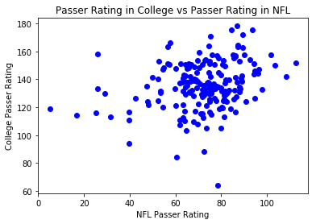

```python
x = df['rating_nfl']
y = df['rating_col']

# set up plot
plt.figure()
plt.xlabel('NFL Passer Rating')
plt.ylabel('College Passer Rating')
plt.title('Passer Rating in College vs Passer Rating in NFL')
plt.scatter(x,y,c="blue");
```

### College TD-Int ratio vs NFL Passer Rating Scatter Plot

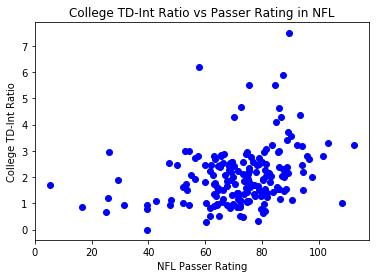

```python
y2 = df['td_int_col']

# set up plot
plt.figure()
plt.xlabel('NFL Passer Rating')
plt.ylabel('College TD-Int Ratio')
plt.title('College TD-Int Ratio vs Passer Rating in NFL')
plt.scatter(x,y2,c="blue");
```

This graph shows a weak but noticable correlation between College TD-Int ratio and NFL Passer Rating

### College Completion Rate vs NFL Passer Rating Scatter Plot

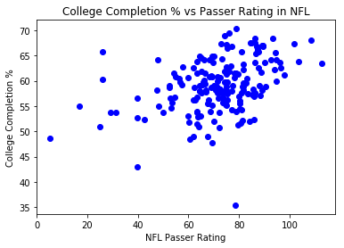

```python
y3 = df['comp_col']

# set up plot
plt.figure()
plt.xlabel('NFL Passer Rating')
plt.ylabel('College Completion %')
plt.title('College Completion % vs Passer Rating in NFL')
plt.scatter(x,y3,c="blue");
```

### Height vs NFL Passer Rating

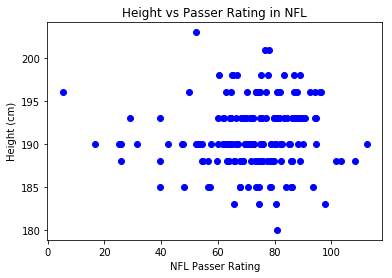

```python
y4 = df['height_cm']

# set up plot
plt.figure()
plt.xlabel('NFL Passer Rating')
plt.ylabel('Height (cm)')
plt.title('Height vs Passer Rating in NFL')
plt.scatter(x,y4,c="blue");
```

This graph shows little correlation between Height and NFL Passer Rating

### Weight vs NFL Passer Rating

[figure not shown]

```python
y5 = df['height_cm']

# set up plot
plt.figure()
plt.xlabel('NFL Passer Rating')
plt.ylabel('Weight (kg)')
plt.title('Weight vs Passer Rating in NFL')
plt.scatter(x,y5,c="blue");
```

### Draft Pick vs NFL Passer Rating

This has no predictive value for this tutorial

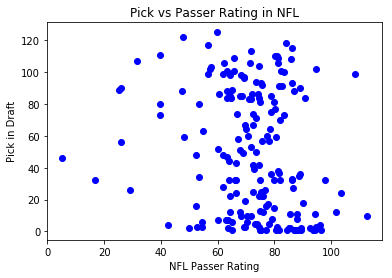

```python
y6 = df['pick']

# set up plot
plt.figure()
plt.xlabel('NFL Passer Rating')
plt.ylabel('Pick in Draft')
plt.title('Pick vs Passer Rating in NFL')
plt.scatter(x,y6,c="blue");
```

### II. Fit Data to Multivariable Linear Regression to predict qbr

Use statsmodels to perform anaylsis

```python
# const for regression analysis
df["const"] = 1

# All X Values (physical / college attributes)
d_X = df[["const","height_cm","weight_kg","comp_col","td_int_col","rating_col"]]

# Target Y Value
d_y = df["rating_nfl"]

# Get regression line
reg = sm.OLS(endog=d_y, exog=d_X, missing='drop')

# Fit Regression
results = reg.fit()

# summarize fitted regression
print(results.summary())
```

```
                            OLS Regression Results
==============================================================================
Dep. Variable:             rating_nfl   R-squared:                       0.189
Model:                            OLS   Adj. R-squared:                  0.166
Method:                 Least Squares   F-statistic:                     8.345
Date:                Thu, 13 Dec 2018   Prob (F-statistic):           4.11e-07
Time:                        07:22:12   Log-Likelihood:                -757.12
No. Observations:                 185   AIC:                             1526.
Df Residuals:                     179   BIC:                             1546.
Df Model:                           5
Covariance Type:            nonrobust
==============================================================================
                 coef    std err          t      P>|t|      [0.025      0.975]
------------------------------------------------------------------------------
const         23.2040     57.488      0.404      0.687     -90.236     136.644
height_cm     -0.1992      0.344     -0.580      0.563      -0.877       0.479
weight_kg      0.2963      0.218      1.361      0.175      -0.133       0.726
comp_col       1.5681      0.348      4.502      0.000       0.881       2.255
td_int_col     3.3102      1.658      1.997      0.047       0.039       6.582
rating_col    -0.3115      0.143     -2.173      0.031      -0.594      -0.029
==============================================================================
Omnibus:                       39.281   Durbin-Watson:                   2.222
Prob(Omnibus):                  0.000   Jarque-Bera (JB):               71.314
Skew:                          -1.046   Prob(JB):                     3.27e-16
Kurtosis:                       5.208   Cond. No.                     1.39e+04
==============================================================================

Warnings:
[1] Standard Errors assume that the covariance matrix of the errors is correctly specified.
[2] The condition number is large, 1.39e+04. This might indicate that there are
strong multicollinearity or other numerical problems.
```

## IV. Residual Analysis / Regression Performance

See how well the regression does in predicting past quarterbacks qbrs in the nfl, and do analysis

### Calculate each row's residual ( ACTUAL - PREDICTED)

#### NOTES:

```
- Positive Residual = Better than predicted
- Negative Residual = Worse than predicted
```

```python
# column for residual
df['rating_residual'] = 0.0

# add residual based on guess
for index, row in df.iterrows():
    x_curr = [row[["const","height_cm","weight_kg","comp_col","td_int_col","rating_col"]]]
    df.at[index,'rating_residual'] = row['rating_nfl'] - (results.predict(x_curr))
df.head(20)
```

|  | round | pick | name | nfl | college | rating_nfl | height_cm | weight_kg | comp_col | td_int_col | rating_col | const | rating_residual |
| --- | --- | --- | --- | --- | --- | --- | --- | --- | --- | --- | --- | --- | --- |
| 2 | 1 | 1 | Baker Mayfield | Browns | Oklahoma | 93.4 | 185 | 97 | 68.5 | 4.366667 | 175.4 | 1 | 11.062116 |
| 3 | 1 | 3 | Sam Darnold | Jets | USC | 69.5 | 190 | 102 | 64.9 | 2.590909 | 153.7 | 1 | -8.559100 |
| 4 | 1 | 7 | Josh Allen | Bills | Wyoming | 62.8 | 196 | 107 | 56.2 | 2.095238 | 137.7 | 1 | -5.245908 |
| 5 | 1 | 10 | Josh Rosen | Cardinals | UCLA | 68.3 | 193 | 98 | 60.9 | 2.269231 | 140.1 | 1 | -4.874885 |
| 6 | 1 | 32 | Lamar Jackson | Ravens | Louisville | 79.9 | 188 | 96 | 57.0 | 2.555556 | 142.9 | 1 | 12.361715 |
| 15 | 1 | 2 | Mitch Trubisky | Bears | North Carolina | 85.0 | 190 | 100 | 67.5 | 4.100000 | 157.6 | 1 | -0.324193 |
| 16 | 1 | 10 | Patrick Mahomes | Chiefs | Texas Tech | 112.5 | 190 | 104 | 63.5 | 3.206897 | 152.0 | 1 | 33.475001 |
| 17 | 1 | 12 | Deshaun Watson | Texans | Clemson | 101.6 | 188 | 99 | 67.4 | 2.812500 | 157.5 | 1 | 20.561360 |
| 18 | 2 | 52 | DeShone Kizer | Browns | Notre Dame | 60.0 | 193 | 106 | 60.7 | 2.473684 | 147.7 | 1 | -13.541652 |
| 20 | 3 | 104 | C.J. Beathard | 49ers | Iowa | 74.6 | 188 | 97 | 58.1 | 2.105263 | 129.8 | 1 | 2.450882 |
| 25 | 1 | 1 | Jared Goff | Rams | California | 94.1 | 193 | 100 | 62.3 | 3.200000 | 144.0 | 1 | 16.270752 |
| 26 | 1 | 2 | Carson Wentz | Eagles | North Dakota State | 92.5 | 196 | 107 | 64.1 | 3.214286 | 153.9 | 1 | 13.407564 |
| 27 | 1 | 26 | Paxton Lynch | Broncos | Memphis | 76.7 | 201 | 110 | 62.9 | 2.565217 | 137.0 | 1 | -3.518972 |
| 29 | 3 | 91 | Jacoby Brissett | Patriots | North Carolina State | 81.6 | 193 | 106 | 59.5 | 3.066667 | 131.3 | 1 | 2.869156 |
| 30 | 3 | 93 | Cody Kessler | Browns | USC | 86.1 | 185 | 97 | 67.5 | 4.631579 | 156.4 | 1 | -1.464510 |
| 31 | 4 | 100 | Connor Cook | Raiders | Michigan State | 83.4 | 193 | 97 | 57.5 | 3.227273 | 139.8 | 1 | 12.588186 |
| 40 | 1 | 1 | Jameis Winston | Buccaneers | Florida State | 87.3 | 193 | 104 | 66.0 | 2.321429 | 163.3 | 1 | 11.402966 |
| 41 | 1 | 2 | Marcus Mariota | Titans | Oregon | 89.5 | 193 | 100 | 66.8 | 7.500000 | 171.8 | 1 | -0.960983 |
| 43 | 3 | 89 | Sean Mannion | Rams | Oregon State | 65.0 | 198 | 101 | 64.6 | 1.537037 | 135.8 | 1 | -12.785471 |
| 44 | 4 | 103 | Bryce Petty | Jets | Baylor | 57.7 | 190 | 102 | 62.7 | 6.200000 | 166.0 | 1 | -25.025230 |

### Best 10 Residuals

An interesting dataframe to see who out performs the most (probably a few familiar names!)

```python
df_best = df.sort_values(['rating_residual'], ascending=False).head(10)
df_best
```

|  | round | pick | name | nfl | college | rating_nfl | height_cm | weight_kg | comp_col | td_int_col | rating_col | const | rating_residual |
| --- | --- | --- | --- | --- | --- | --- | --- | --- | --- | --- | --- | --- | --- |
| 16 | 1 | 10 | Patrick Mahomes | Chiefs | Texas Tech | 112.5 | 190 | 104 | 63.5 | 3.206897 | 152.0 | 1 | 33.475001 |
| 421 | 4 | 99 | Doug Gaynor | Bengals | Long Beach State | 108.3 | 188 | 92 | 68.1 | 1.000000 | 141.8 | 1 | 29.347898 |
| 149 | 2 | 64 | Tarvaris Jackson | Vikings | Alabama State | 78.5 | 188 | 102 | 35.4 | 0.333333 | 64.1 | 1 | 25.867241 |
| 158 | 1 | 24 | Aaron Rodgers | Packers | California | 103.4 | 188 | 102 | 63.8 | 3.307692 | 150.3 | 1 | 23.235736 |
| 218 | 2 | 32 | Drew Brees | Chargers | Purdue | 97.8 | 183 | 94 | 61.1 | 2.000000 | 132.5 | 1 | 22.029092 |
| 350 | 4 | 84 | Troy Taylor | Jets | California | 90.6 | 193 | 90 | 58.8 | 1.108696 | 124.1 | 1 | 21.947055 |
| 121 | 1 | 3 | Matt Ryan | Falcons | Boston College | 94.6 | 193 | 98 | 59.9 | 1.513514 | 126.2 | 1 | 21.165470 |
| 110 | 1 | 1 | Matthew Stafford | Lions | Georgia | 88.4 | 190 | 99 | 57.1 | 1.545455 | 133.3 | 1 | 20.567883 |
| 17 | 1 | 12 | Deshaun Watson | Texans | Clemson | 101.6 | 188 | 99 | 67.4 | 2.812500 | 157.5 | 1 | 20.561360 |
| 253 | 1 | 1 | Peyton Manning | Colts | Tennessee | 96.5 | 196 | 104 | 62.5 | 2.696970 | 147.1 | 1 | 20.400016 |

### Worst 10 Residuals

Not so many familiar names....

```python
df_worst = df.sort_values(['rating_residual'], ascending=True).head(10)
df_worst
```

|  | round | pick | name | nfl | college | rating_nfl | height_cm | weight_kg | comp_col | td_int_col | rating_col | const | rating_residual |
| --- | --- | --- | --- | --- | --- | --- | --- | --- | --- | --- | --- | --- | --- |
| 315 | 2 | 46 | Tony Sacca | Cardinals | Penn State | 5.3 | 196 | 104 | 48.7 | 1.708333 | 119.1 | 1 | -54.608671 |
| 123 | 2 | 56 | Brian Brohm | Packers | Louisville | 26.0 | 190 | 102 | 65.8 | 2.958333 | 157.9 | 1 | -53.378497 |
| 368 | 2 | 32 | Mike Elkins | Chiefs | Wake Forest | 16.7 | 190 | 100 | 54.9 | 0.860000 | 114.0 | 1 | -51.720877 |
| 502 | 4 | 90 | Tom Flick | Redskins | Washington | 25.9 | 188 | 86 | 60.3 | 1.200000 | 133.4 | 1 | -42.321288 |
| 261 | 1 | 26 | Jim Druckenmiller | 49ers | Virginia Tech | 29.2 | 193 | 109 | 53.8 | 1.888889 | 130.1 | 1 | -37.956780 |
| 521 | 4 | 89 | Rusty Lisch | Cardinals | Notre Dame | 25.1 | 190 | 96 | 51.0 | 0.666667 | 116.1 | 1 | -34.725913 |
| 318 | 4 | 107 | Will Furrer | Bears | Virginia Tech | 31.4 | 190 | 95 | 53.7 | 0.934783 | 113.1 | 1 | -34.185335 |
| 100 | 4 | 122 | Mike Kafka | Eagles | Northwestern | 47.7 | 190 | 97 | 64.1 | 0.950000 | 123.9 | 1 | -31.472737 |
| 296 | 4 | 111 | Perry Klein | Falcons | C.W. Post | 39.6 | 188 | 98 | 52.7 | 0.000000 | 94.0 | 1 | -28.559229 |
| 192 | 3 | 88 | Dave Ragone | Texans | Louisville | 47.4 | 190 | 111 | 58.1 | 2.551724 | 134.8 | 1 | -28.420072 |

## V. Graphical Examination of Residual Performance

Look at the distribution of residuals using violinplots to see how well it is capturing the data

### All Together

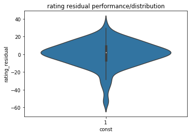

```python
## Create violin plot of residuals to see overall accuracy
## against 1 (all together)
plt.figure()
sns.violinplot(x = 'const', y='rating_residual', data = df).set_title('rating residual performance/distribution');
```

This shows the regression is fairly good at predicting nfl qbr, as the highest density of cases is around a residual of 0

### By Round

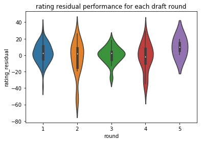

```python
## Create violin plot of residuals for each round of draft picks
plt.figure()
sns.violinplot(x = 'round', y='rating_residual', data = df).set_title('rating residual performance for each draft round');
```

- It seems that rounds 1 and 3 are most accurately predicted.
- One interesting note is that round 5 is too high, which could signify the need for other factors, such as player IQ or intangibles that were not looked at in this investigation, but resulted in the player being drafted later on in the draft

## 3. Exploration:

### Predicting 2019 Draft Big Board based on QBR

### I. Extracting Player's Collegiant Data:

Data is from: https://www.sports-reference.com/cfb/ (used earlier for previously drafted players as well)

Differences:

- DataFrame is not yet made, so data is simply added to arrays that will be used during the creation of the dataframe later
- candidate array is iterated over
- candidates are held in tuples (NAME, SCHOOL), so name and school information is extracted slightly differently
- Height and weight are extracted from this site. Although it is the cfb version, the same exact procedure is used as on: https://www.pro-football-reference.com/

As stated in the comments, the candidates are hand chosen. I just looked on the internet for a few big boards and threw in the most common names. Kyler Murray (this years Heisman Trophy winner) isn't on any lists because he is playing professional baseball, but I was interested on how he would stack up, so I threw him in there as well.

```python
## candidates: found from web research and manually inputted
candidates = [("Justin Herbert","Oregon"), ("Dwayne Haskins", "Ohio State"), \
              ("Daniel Jones", "Duke"), ("Will Grier", "West Virginia"), ("Drew Lock", "Missouri"), \
              ("Ryan Finley", "North Carolina State"), ("Kyler Murray", "Oklahoma")]

# arrays to populate for dataframe
names = []
heights = []
weights = []
comp_percs = []
td_ints = []
ratings = []

# iterate through candidates
for qb,school in candidates:

    # extract name and school
    name = qb.split()
    firstname = name[0].lower()
    lastname = name[1].lower()
    names.append(name[0] + " " + name[1])
    school = school.lower()

    # access search url
    url = "https://www.sports-reference.com/cfb/search/search.fcgi?hint=" + firstname + "+" + lastname + "&search=" + firstname + "+" + lastname + "&pid=&idx="
    r = requests.get(url,headers=headers)
    # use beautiful soup to get the contents of the page
    root = BeautifulSoup(r.content)
    table = root.find('div',class_="search-results")

    # non-unique name --> find correct search result
    if(table!= None):

        # get correct search result
        table = str(table).lower().replace("\n","")
        elements = table.split("<a")
        link_data = ""
        regex = r"href=\"(.*)\">(<strong>){0,1}" + firstname + " " + lastname
        for ele in elements:
            if(school in ele):
                link_data = ele

        # get player bio url info from result
        data = re.findall(regex,link_data)[0]
        url2 = 'https://www.sports-reference.com' + data[0]

        # access bio
        r2 = requests.get(url2,headers=headers)
        root = BeautifulSoup(r2.content)

        # get data from table (same as before)
        table = str(root.find('table').find('tfoot'))
        regex = r"<tr[\s\S]*?career[\s\S]*?\"pass_cmp_pct\">([0-9\.]*)<[\s\S]*?\"pass_td\">([0-9]*)<[\s\S]*?\"pass_int\">([0-9]*)<[\s\S]*?\"pass_rating\">([0-9\.]*)<[\s\S]*?<\/tr>"
        data = re.findall(regex,str(table).lower())[0]
        rate = data[3]
        td = data[1]
        ints = data[2]
        comps = data[0]

        # append data to arrays rather than using dataframes
        ratings.append(float(rate))
        td_ints.append(float(td) / float(ints))
        comp_percs.append(float(comps))

        # append height and weight data in same procedure as before
        info = str(root.find('div', id="info"))
        regex = r"([0-9]*)cm,\W*([0-9]*)kg"
        data = re.findall(regex,info)[0]
        heights.append(int(data[0]))
        weights.append(int(data[1]))


    # unique name, at player's bio
    else:

        # get data from table (same as before)

        table = str(root.find('table').find('tfoot'))
        regex = r"<tr[\s\S]*?career[\s\S]*?\"pass_cmp_pct\">([0-9\.]*)<[\s\S]*?\"pass_td\">([0-9]*)<[\s\S]*?\"pass_int\">([0-9]*)<[\s\S]*?\"pass_rating\">([0-9\.]*)<[\s\S]*?<\/tr>"
        data = re.findall(regex,str(table).lower())[0]
        rate = data[3]
        td = data[1]
        ints = data[2]
        comps = data[0]

        # append data to arrays rather than using dataframes
        ratings.append(float(rate))
        td_ints.append(float(td) / float(ints))
        comp_percs.append(float(comps))

        # append height and weight data in same procedure as before
        info = str(root.find('div', id="info"))
        regex = r"([0-9]*)cm,\W*([0-9]*)kg"
        data = re.findall(regex,info)[0]
        heights.append(int(data[0]))
        weights.append(int(data[1]))
```

### II. Put extracted data into dataframe

```python
d_in = {'name': names, 'height_cm': heights, 'weight_kg': weights, 'comp_col': comp_percs, 'td_int_col': td_ints, 'rating_col': ratings}
cand_df = pd.DataFrame(d_in)
cand_df
```

|  | name | height_cm | weight_kg | comp_col | td_int_col | rating_col |
| --- | --- | --- | --- | --- | --- | --- |
| 0 | Justin Herbert | 198 | 105 | 62.7 | 3.647059 | 152.9 |
| 1 | Dwayne Haskins | 190 | 99 | 70.2 | 5.666667 | 175.5 |
| 2 | Daniel Jones | 196 | 99 | 59.5 | 1.740741 | 120.6 |
| 3 | Will Grier | 188 | 101 | 65.7 | 3.521739 | 165.2 |
| 4 | Drew Lock | 193 | 102 | 56.8 | 2.461538 | 138.1 |
| 5 | Ryan Finley | 193 | 96 | 64.3 | 2.214286 | 139.4 |
| 6 | Kyler Murray | 178 | 88 | 68.7 | 3.428571 | 184.6 |

### III. Predict NFL QBR using Regression

Use the regression previously created to populate new column in dataframe. Add constant column for regression execution

```python
cand_df['projected_qbr'] = 0.0
cand_df['const'] = 1
for index,row in cand_df.iterrows():
    x_curr = [row[["const","height_cm","weight_kg","comp_col","td_int_col","rating_col"]]]
    cand_df.at[index,'projected_qbr'] = (results.predict(x_curr))
cand_df
```

|  | name | height_cm | weight_kg | comp_col | td_int_col | rating_col | projected_qbr | const |
| --- | --- | --- | --- | --- | --- | --- | --- | --- |
| 0 | Justin Herbert | 198 | 105 | 62.7 | 3.647059 | 152.9 | 77.650099 | 1 |
| 1 | Dwayne Haskins | 190 | 99 | 70.2 | 5.666667 | 175.5 | 88.872542 | 1 |
| 2 | Daniel Jones | 196 | 99 | 59.5 | 1.740741 | 120.6 | 75.002441 | 1 |
| 3 | Will Grier | 188 | 101 | 65.7 | 3.521739 | 165.2 | 78.915045 | 1 |
| 4 | Drew Lock | 193 | 102 | 56.8 | 2.461538 | 138.1 | 69.190577 | 1 |
| 5 | Ryan Finley | 193 | 96 | 64.3 | 2.214286 | 139.4 | 77.949860 | 1 |
| 6 | Kyler Murray | 178 | 88 | 68.7 | 3.428571 | 184.6 | 75.407979 | 1 |

#### Sort

```python
cand_df = cand_df.sort_values(['projected_qbr'], ascending=False)
cand_df
```

|  | name | height_cm | weight_kg | comp_col | td_int_col | rating_col | projected_qbr | const |
| --- | --- | --- | --- | --- | --- | --- | --- | --- |
| 1 | Dwayne Haskins | 190 | 99 | 70.2 | 5.666667 | 175.5 | 88.872542 | 1 |
| 3 | Will Grier | 188 | 101 | 65.7 | 3.521739 | 165.2 | 78.915045 | 1 |
| 5 | Ryan Finley | 193 | 96 | 64.3 | 2.214286 | 139.4 | 77.949860 | 1 |
| 0 | Justin Herbert | 198 | 105 | 62.7 | 3.647059 | 152.9 | 77.650099 | 1 |
| 6 | Kyler Murray | 178 | 88 | 68.7 | 3.428571 | 184.6 | 75.407979 | 1 |
| 2 | Daniel Jones | 196 | 99 | 59.5 | 1.740741 | 120.6 | 75.002441 | 1 |
| 4 | Drew Lock | 193 | 102 | 56.8 | 2.461538 | 138.1 | 69.190577 | 1 |

### IV. Deliberable: Draft Board

Index represents their position ranking

```python
projected_big_board = cand_df[['name','projected_qbr']]
projected_big_board = projected_big_board.reset_index(drop=True)
projected_big_board.index += 1
projected_big_board
```

|  | name | projected_qbr |
| --- | --- | --- |
| 1 | Dwayne Haskins | 88.872542 |
| 2 | Will Grier | 78.915045 |
| 3 | Ryan Finley | 77.949860 |
| 4 | Justin Herbert | 77.650099 |
| 5 | Kyler Murray | 75.407979 |
| 6 | Daniel Jones | 75.002441 |
| 7 | Drew Lock | 69.190577 |

### V. How They Stack Up

- Graph distribution of all nfl passer ratings in the original dataframe (storing already drafted qbs)
- plot current Draft candidates on distribution to see where they line up relevant to historical qbrs

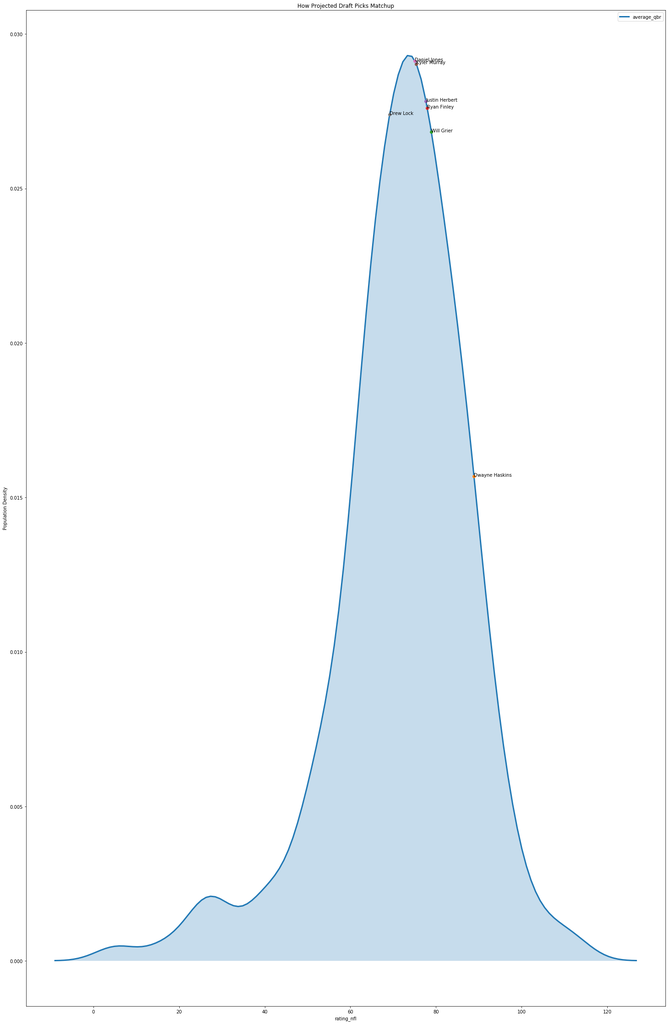

```python
# get all nfl passer ratings
all_qbr = df['rating_nfl']

# set plot size larger to see names properly
plt.figure(figsize=(25,40))
# graph info
plt.xlabel('NFL Passer Rating')
plt.ylabel('Population Density')
plt.title('How Projected Draft Picks Matchup')

# use seaborn to create distribution plot
ax = sns.distplot(all_qbr, hist = False, kde = True, kde_kws = {'shade': True, 'linewidth': 3}, label="average_qbr");

# get x, y datapoints of distribution plot line
data_x, data_y = ax.lines[0].get_data()

# plot where they projected qbr lines up relevant to distribution
for index,row in projected_big_board.iterrows():
    xi = row['projected_qbr']
    # interpret y value with numpy
    yi = np.interp(xi,data_x, data_y)
    ax.plot(xi,[yi], marker="o")
    ax.annotate(row['name'], (xi,yi))
plt.show()
```

## Thank you for reading! Please let me know if you have any comments or questions!

### email: jaredcirulli@yahoo.com